# Revisão de números complexos

Renato Naville Watanabe

Um número complexo pode ser expresso de diferentes formas. A forma mais comum (e menos útil para nós) é a forma cartesiana:

$z = x + jy$

Nessa representação, $x$ é a parte real de $z$ ($x=\Re\{z\}$), $y$ é a parte imaginária de $z$ ($y = \Im\{z\}$) e $j = \sqrt{-1}$ é a unidade imaginária.

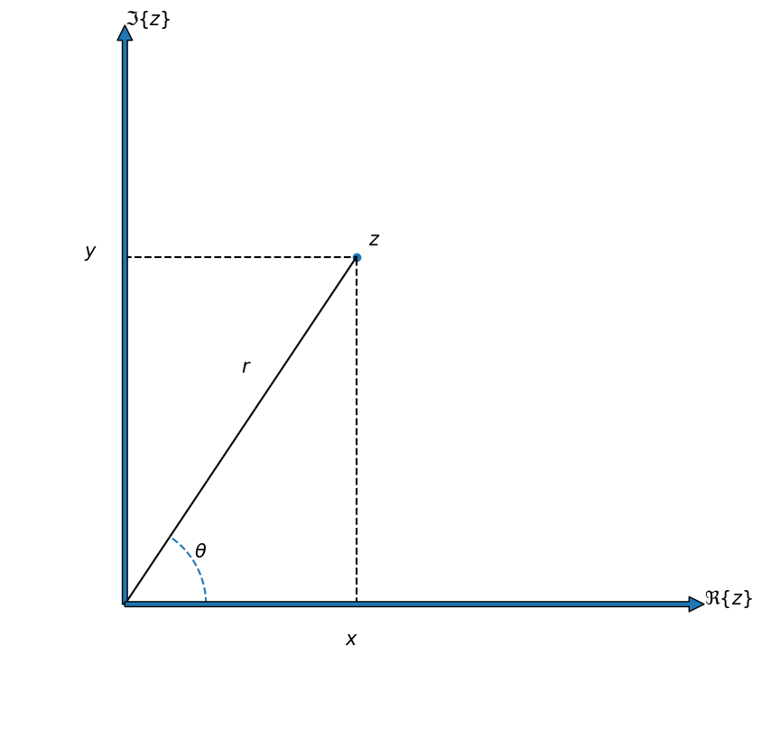

Na figura acima é mostrado o plano complexo. Nele a parte real é a abscissa e parte imaginária é a ordenada. Como é possível observar o número $z$ pode pode ser escrito como:

$$z = r\cos(\theta)+rj\mathrm{sen}(\theta) = r(\cos(\theta)+j\mathrm{sen}(\theta))$$

Nessa representação é fácil ver qual o módulo de $z$: $|z| = \sqrt{x^2+y^2} = \sqrt{r^2\cos(\theta)^2+r^2\mathrm{sen}(\theta)^2} = r$. Isso vem do Teorema de Pitágoras.

Dessa forma, é possível notar que um número complexo $z$ pode ser representado por dois números: o seu módulo $r$ e a sua fase $\theta$.

A partir da última relação chegamos a uma outra forma de representar um número complexa: a forma polar com exponencial complexa. Essa relação é a mais útil para nós, pois permite mexer com números complexos de forma mais simples e nos trazer mais informações do que na forma polar (apesar de não ser muito intuitiva). Essa relação vem da fórmula de Euler-Moivre:

$$z = r\cos(\theta) + jr\mathrm{sen}(\theta) = re^{j\theta}$$

Essa relação pode ser demonstrada, por exemplo, utilizando Séries de Taylor.

A relação entre as duas formas se dá pelas seguintes expressões:

- o valor de $r$ é o valor de |z| (módulo de $z$): $r = \sqrt{x^2+y^2}$
- o valor de $\theta$ é a o valor de $\phase{z}$ (fase de $z$): $\theta = \arctan\left(\frac{y}{x} \right)$
- $x$ é a parte real de $z$: $x = r\cos(\theta)$
- $y$ é a parte imaginária de $z$: $y = r\mathrm{sen}(\theta)$

Outra relação é que o complexo conjugado de um número $z$ é o número com fase com o sinal trocado: $z = re^{j\theta} \rightarrow \bar{z} = re^{-j\theta}$.

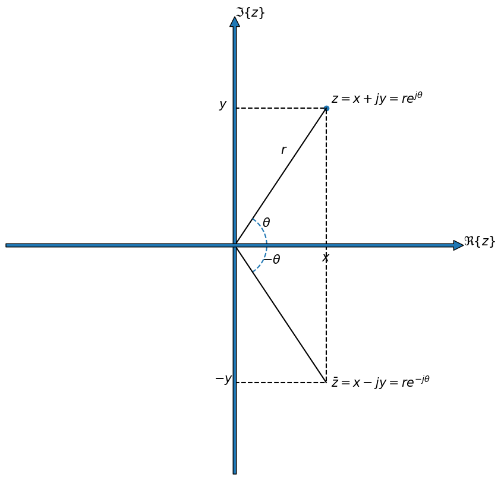

Observando o plano complexo abaixo, vemos quatro igualdades:

- $1 = e^{j0}$
- $-1 = e^{j\pi}$
- $j = e^{j\frac{\pi}{2}}$
- $-j = e^{-j\frac{\pi}{2}}$

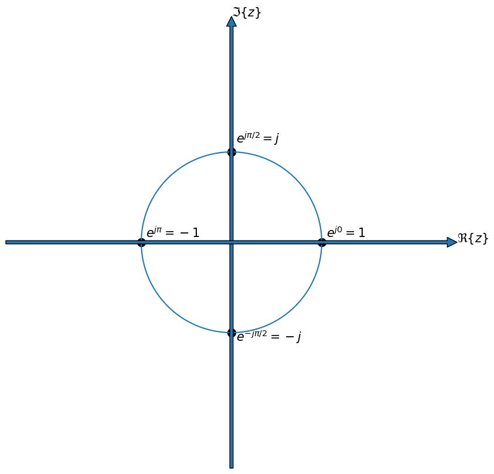

Elevar um número complexo a uma potência é mais simples usando a representação polar. Elevar um número complexo à potência $p$ equivale simplesmente a multiplicar o ângulo $\theta$ por $p$.

### Exemplo 1

Elevar $z=e^{j\frac{\pi}{4}}$ ao cubo é:

$z^3=\left(e^{j\frac{\pi}{4}}\right)^3 = e^{j\frac{3\pi}{4}}$

Fazer essa operação na representação cartesiana seria muito complicado, mas na representação polar é uma simples multiplicação.

É claro que se o módulo $r$ de um número for diferente de 1, esse módulo também é elevado à mesma potência.

### Exemplo 2

$z = 4e^{j\pi/6} \rightarrow z^4 = (4e^{j\pi/6})^4 = 256e^{j2\pi/3}$

[video not shown]

## Produtos e quocientes

Uma forma frequentemente encontrada na prática são produtos e quocientes de números complexos.

$z = \frac{z_{n_1}z_{n_2}z_{n_3}...z_{n_k}}{z_{d_1}z_{d_2}z_{d_3}...z_{n_m}}$

Nesses casos, o módulo de $z$ é:

$|z| = \frac{|z_{n_1}||z_{n_2}||z_{n_3}|...|z_{n_k}|}{|z_{d_1}||z_{d_2}||z_{d_3}|...|z_{n_m}|}$

e a fase de $z$ é:

$\angle{z} = \phase{z_{n_1}}+\phase{z_{n_2}}+\phase{z_{n_3}}+...+\phase{z_{n_k}}-\phase{z_{d_1}}-\phase{z_{d_2}}-\phase{z_{d_3}}-...-\phase{z_{n_m}}$

A prova dessas expressões fica como exercício.

## #

### Exemplo 3

Considere o seguinte número complexo:

$z = \frac{(1+j)^2(1-j\sqrt{3})}{(\sqrt{3}+j)(2+j8)(1-j)}$

Para ficar mais fácil, vamos passar cada termo para a representação polar:

$1+j = \sqrt{2}e^{j\frac{\pi}{4}}$

$1-j\sqrt{3} = 2e^{j\frac{\pi}{3}}$

$\sqrt{3}+1j = 2e^{j\frac{\pi}{6}}$

$2+j8 = \sqrt{20}e^{j\arctan{4}} = \sqrt{20}e^{j1.33}$

$1-j = \sqrt{2}e^{-j\frac{\pi}{4}}$

Então o número $z$ pode ser reescrito como:

$z = \frac{\sqrt{2}e^{j\frac{\pi}{2}}2e^{j\frac{\pi}{3}}}{2e^{j\frac{\pi}{6}}\sqrt{20}e^{j1.33}\sqrt{2}e^{-j\frac{\pi}{4}}}$

Então o módulo de $z$ é:

$|z| = \frac{\sqrt{2}2}{2\sqrt{20}\sqrt{2}} = \frac{1}{\sqrt{20}}$

E a fase é:

$\phase{z} = \frac{\pi}{2} + \frac{\pi}{3} - \frac{\pi}{6}-1.33+\frac{\pi}{4} = \frac{11\pi}{12}-1.33 = 1.55$ rad

## Referências

- Oppenheim, M. e Willsky, S., Sistemas e Sinais, 2010
- Brown, James, e Ruel Churchill. Variáveis complexas e aplicações. (9ª edição), 2015.